# Basic Review of Statistical Inference

# Introduction

From [Wikipedia](https://en.wikipedia.org/wiki/Statistical_inference):

Statistical inference makes propositions about a population, using data drawn from the population with some form of sampling. Given a hypothesis about a population, for which we wish to draw inferences, statistical inference consists of (first) selecting a statistical model of the process that generates the data and (second) deducing propositions from the model. Inferential statistical analysis **infers properties of a population**, for example by testing hypotheses and deriving estimates. It is assumed that the observed data set is sampled from a larger population.

More technically, statistical inference is the process of using data analysis to deduce properties of an underlying **probability distribution** (which is a form of model).

A key aspect of inferential procedures is in constructing or approximating the **sampling distribution** for sample statistics or model parameters.

**Point:** Explain the idea of a sampling distribution with a concrete example.

**Note:** In supervised learning, the goal is usually prediction rather than inference although inferential procedures might still play a roll in model evaluation and assessment.

# Traditional Statistics

## One-sample Example

Suppose that we want to know how many times a day, on a typical week day, students patron Starbucks during the semester. In order to study this question, we randomly select 30 different students on random week days and ask how many times they visited Starbucks that day. Some students will not have visited Starbucks and some will have visited several times. **Our goal is to infer the average number of times.**

Here is some (fake) data:

```r
set.seed(4321)
p_mu <- 3
sig_val <- 1.5
n <- 30
x_vals <- rnorm(n,mean=p_mu,sd=sig_val)
mean_x <- mean(x_vals)
```

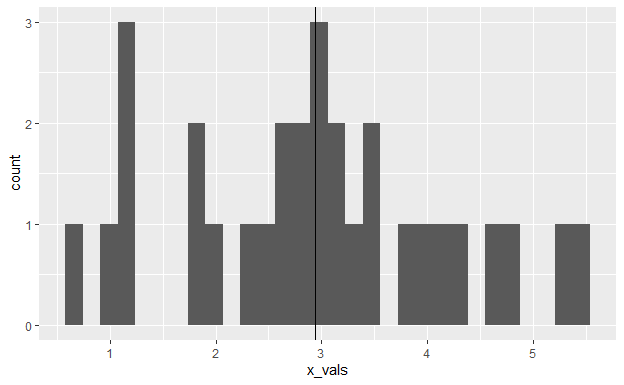

```r
ggplot(data=NULL,mapping=aes(x=x_vals)) + geom_histogram() + geom_vline(xintercept = mean_x)
```

We see that the sample mean is

```r
mean_x
```

```
[1] 2.937231
```

We might hypothesize that the true population mean is 3, and in fact this is the case in this example becuase we sampled the data from a normal distribution with mean of 3.

**Question:** Does the data provide supporting evidence for this hypothesis? If we use the sample mean as an estimate for the population mean, how reliable of an estimate to the population value is provided by using the sample mean. This is the problem we will address.

## Two-sample Example

Suppose that we want to measure the effect of the growth of a particular type of plant under two different lighting conditions.

In order to do this, we conduct the following experiment:

- Obtain 50 young plants all of roughly the same “age”
- Divide these into two groups of 25 each
- Place one of the groups of 25 plants under lighting condition 1 and place the other group of 25 plants under lighting condition 2
- After a certain amount of time, measure the height of each of the 50 plants

One way to compare the outcome is to compute the difference in the mean of the meaured heights between the two groups.

We will simulate some data to get a feel for this:

```r
data_df <- data.frame(Light_condition=factor(c(rep("Condition_One",25),rep("Condition_Two",25))),Plant_height=c(rnorm(25,mean=14,sd=3.7),rnorm(25,mean=12.7,sd=3.7)))
```

A plot is helpful:

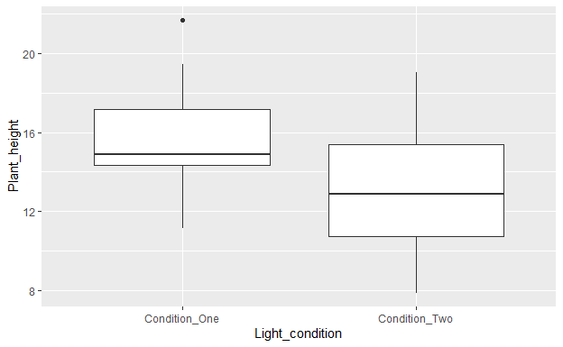

```r
data_df %>%  ggplot(aes(x=Light_condition,y=Plant_height)) + geom_boxplot()
```

**Question:** Is the observed difference due to some real effect or could it be due to random chance? This is the problem of statistical significance.

Here is a plot of the mean for each lighting condition:

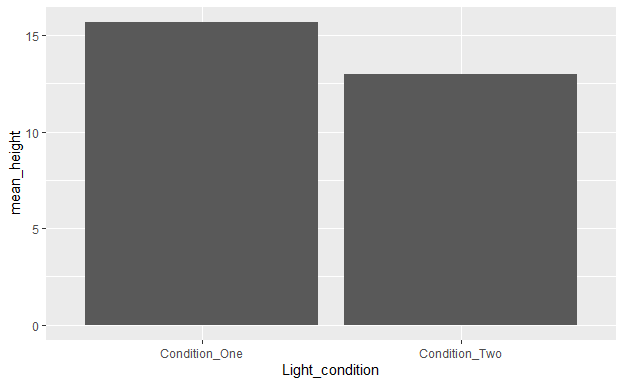

```r
data_df %>% group_by(Light_condition) %>% summarise(mean_height=mean(Plant_height)) %>% ggplot(aes(x=Light_condition,y=mean_height)) +
  geom_bar(stat = "identity")
```

# Traditional Inference

There are two common inferrential procedures, **hypothesis testing** and **confidence intervals** for estimates. We will look at some examples and then explain in a general sense what is the meaning of these terms. Our preference here is to use **simulation** and **resampling** rather than formal analytic constructs to understand tests of hypothesis and confidence intervals.

## One-sample Example

In our Starbucks example, we use the sample mean as an estimate for the population mean and then derive a confidence interval that provides a range of potential values of the (unknown) population mean.

There are different ways to do this depending on what is know or assumed to be true about the data.

If we can reasonably assume that the data is **normally distributed with known variance** (or standard deviation), then a 95% confidence interval for the population mean is computed as follows:

```r
ci_percent <- 0.95
alpha_half <- (1 - ci_percent)/2
z_alpha_half <- qnorm(1-alpha_half)
CI_result <- mean_x + c(-1,1)*z_alpha_half*sig_val/sqrt(n) # "z" formula for confidence interval
CI_result
```

```
[1] 2.400473 3.473989
```

If we reasonably assume that the data is normally distributed with **unknown** variance (or standard deviation), then a 95% confidence interval for the population mean is computed as follows:

```r
std_err <- sd(x_vals)
t_alpha_half <- qt(1-alpha_half,n-1)
CI_result_t <- mean_x + c(-1,1)*t_alpha_half*std_err/sqrt(n) # "t" formula for confidence interval
CI_result_t
```

```
[1] 2.461002 3.413461
```

This information plus more can be obtained from the t.test function in R of which we will have more to say in the future.

```r
confint(t.test(x_vals,mu=p_mu,conf.level = ci_percent))
```

| mean of x | lower | upper | level |
| --- | --- | --- | --- |
| 2.937231 | 2.461002 | 3.413461 | 0.95 |

For now do not worry about the details of the functions t.test or confint, we just want to use the result for comparison with the bootstrap and permutation test procedures discussed later. One thing to note is that the t.test is based on formulas derived using asymptotic analysis of analytical distribution functions.

Shortly, we will see a third approach that makes fewer assumptions about the data, the so-called **bootstrap** approach. The bootstrap approach does not require us to remember the analytic formulas derived from asymptotic analysis of certain known distributions.

## Two-sample Example

In the “plant growth under different lighting conditions” example, we are interested in **the difference in means** between the two samples.

A common way to study this problem is by using a t-test:

```r
x <- data_df %>% filter(Light_condition == "Condition_One") %>% select(Plant_height) %>% unlist()
y <- data_df %>% filter(Light_condition == "Condition_Two") %>% select(Plant_height) %>% unlist()

(mean_xx<-mean(x))
```

```
[1] 15.66849
```

```r
(mean_yy<-mean(y))
```

```
[1] 12.97181
```

```r
(sample_diff <- mean_xx - mean_yy)
```

```
[1] 2.696684
```

```r
confint(t.test(x,y))
```

| mean of x | mean of y | lower | upper | level |
| --- | --- | --- | --- | --- |
| 15.66849 | 12.97181 | 1.171738 | 4.221629 | 0.95 |

Again, do not worry about the details of confint and t.test, we just want to use this result as a point of comparison for the bootstrap and permutation test discussed below.

# Bootstrap Confidence Intervals

Mathematical statistics derives analytic formulas that can be used to compute values of interest in statistical inference. This is often done by making specific assumptions or using asymptotic results to derive or approximate the sampling distributions of the most common sample statistics. For example, this approach leads to the t-test that we hinted at before.

Instead, we will take a computational approach that uses simulation and resampling procedures to approximate the sampling distribution of a statistic of interest. There are two common resampling methods:

1. Bootstrap methods which use **sampling with replacement** and are typically used to approximate confidence intervals although bootstrap methods can be used for hypothesis testing
2. Permutation tests which use **sampling without replacement** and are used for testing statistical hypotheses and approximating p-values

Resampling methods are well-suited for applications in data science since 1) in these applications there is often access to a large amount of data 2) the distributional assumptions necessary for analytical procedures can’t be made 3) the statistics of interest do not follow known distributions

We look at the bootstrap method first and apply it to the two example problems we have introduced.

## Bootstrap

**The Bootstrap Idea:** The original sample approximates the population from which it was drawn. So resamples from this sample approximate what we would get if we took many samples from the population. The bootstrap distribution, based on many resamples, approximates the sampling distribution of the statistic, based on many samples.

**Bootstrap for a Single Population:** Given a sample of size $n$ from a population:

1. Draw a resample of size $n$ with replacement from the sample. Compute a statistic that describes the sample, for example the sample mean.
2. Repeat this resampling process many times, say 5,000 or 10,000.
3. Construct the boostrap distribution of the statistic. Inspect its center, spread, and shape.

### One-sample Example Bootstrap

```r
boot_result <- do(5000)*mean(sample(x_vals,replace = TRUE)) # repeatedly sample with replacement and compute mean
head(boot_result)
```

|  | mean |
| --- | --- |
| 1 | 2.844955 |
| 2 | 2.900646 |
| 3 | 2.994740 |
| 4 | 3.120325 |
| 5 | 2.840221 |
| 6 | 2.651368 |

Here is a hisogram for our bootstrap resampled means that illustrates what the bootstrap distribution looks like

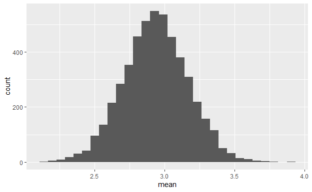

```r
boot_result %>% ggplot(aes(x=mean)) + geom_histogram()
```

We can use this to approximate the confidence interval for the mean by approximating the *bootstrap percentile confidence interval* by computing the percentiles from our resampled bootstrap means.

```r
CI_result_boot <- stats::quantile(boot_result$mean,c(0.025,0.975))

CI_result_boot
```

```
    2.5%    97.5%
2.485735 3.382468
```

Compare this result with what we obtained using analytic formulas: z-formula

```r
CI_result
```

```
[1] 2.400473 3.473989
```

t-formula

```r
CI_result_t
```

```
[1] 2.461002 3.413461
```

Using the bootstrap percentile confidence interval to estimate a confidence interval for a parameter might lead to inaccuracy. There are adjustments that can be made to improve accuracy and these are implemented in the boot package for R which contains function to carry out the bootstrap and compute bootstrap confidence intervals. Here is an example use:

```r
library(boot)
```

```r
my_mean_w <- function(x,w) sum(x*w)

boot_CI <- boot.ci(boot(data=x_vals, statistic=my_mean_w, R=5000,stype = "w"), conf = ci_percent,type="basic")

boot_CI
```

```
BOOTSTRAP CONFIDENCE INTERVAL CALCULATIONS
Based on 5000 bootstrap replicates

CALL :
boot.ci(boot.out = boot(data = x_vals, statistic = my_mean_w,
    R = 5000, stype = "w"), conf = ci_percent, type = "basic")

Intervals :
Level      Basic
95%   ( 2.470,  3.367 )
Calculations and Intervals on Original Scale
```

A two-sample boostrap works in a similar fashion but now we just have to take resamples from multiple populations. We demonstrate this with an example.

### Two-sample Example Bootstrap

```r
N <- 5000
boot_mean_diffs <- numeric(N)
for (i in 1:N){
  temp_x <- sample(x,replace = T)
  temp_y <- sample(y,replace = T)
  boot_mean_diffs[i] <- mean(temp_x) - mean(temp_y)
}
quantile(boot_mean_diffs,c(0.025,0.975))
```

```
    2.5%    97.5%
1.248774 4.126444
```

Compare with results obtained from the analytically derived t-test method:

```r
confint(t.test(x,y))
```

| mean of x | mean of y | lower | upper | level |
| --- | --- | --- | --- | --- |
| 15.66849 | 12.97181 | 1.171738 | 4.221629 | 0.95 |

## Permutation Test

Before we explain the idea of permutation tests, let’s recall the general idea of hypothesis testing (aka significance testing).

The **null hypothesis**, denoted $H_{0}$, is a statement that corresponds to **no real effect**. This is the status quo, in the absence of the data providing convincing evidence to the contrary. The **alternative hypothesis**, denoted $H_{A}$, is a statement that there is a real effect. The data may provide convincing evidence that this hypothesis is true.

In statistical hypothesis testing we seek to determine if the data provides strong enough evidence to **reject** the null hypothesis. Thus there are only two options: Reject the null or fail to reject the null.

Let’s think about this in the context of our plant growth example. In this example

$H_{0}$ - there is no significance difference in growing plants under the two different lighting conditions, mathematically this is stated as the difference in population means is zero

$H_{A}$ - there is a significance difference in growing plants under the two different lighting conditions, mathematically this is stated as the difference in population means is non-zero

We must make a decision based on out data whether to reject of fail to reject the null hypothesis. This decision is typically made using a confidence level and corresponding p-value. The confidence level and p-value provide a threshold for deciding when, under the assumption that the null hypothesis is true, the outcome (*e.g.* sample statistic value) observed from the sample data is **exceptionally** rare.

The permutation test is easier to understand in the two-sample case so we begin with it.

### Two-sample Example Permutation Test

Notice that the total number of possible permutations from 50 observations is:

```r
factorial(50)
```

```
[1] 3.041409e+64
```

We don’t actually need to consider all possible permutations to obtain an accurante approximation for a p-value.

```r
N <- 5000
samp_diffs <- numeric(N)
for (i in 1:N){
  m_vals <- sample(data_df$Plant_height) # samp without replacement
  h_x <- m_vals[1:25]
  h_y <- m_vals[26:50]
  samp_diffs[i] <- mean(h_x) - mean(h_y)
}
samp_diffs_df <- data.frame(samp_diffs=samp_diffs)
```

We can visualize the permutation distribution of the resampled difference in means:

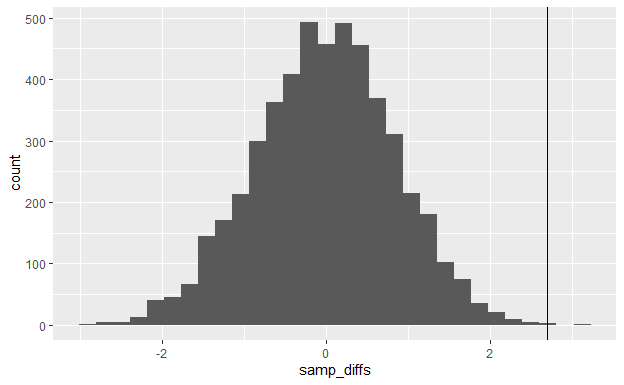

```r
samp_diffs_df %>% ggplot(aes(x=samp_diffs)) +
  geom_histogram() +
  geom_vline(xintercept = sample_diff)
```

```r
2*(sum(samp_diffs_df$samp_diffs >= sample_diff))/N
```

```
[1] 8e-04
```

Using the traditional method for testing this is with a two-sample t-test:

```r
t.test(x,y)$p.value
```

```
[1] 0.0008622
```

In either case would reject the null hypothesis that there is no difference in the means.

### Bootstrap t-test

As we mentioned the bootstrap can be used to conduct hypothesis testing. It works by selecting an appropriate sample statistic. For example, if we compute a t-statistic the bootstrap leads to a bootstrap t-test.

Let’s look at this in the context of our one-sample Starbucks data: First we compute the observed sample t-value

```r
(test_t <- (mean_x - p_mu)/(sd(x_vals)/sqrt(n)))
```

```
[1] -0.2695685
```

Now do the bootstrap resampling (remember this is sampling with replacement)

```r
boot_t_vals <- numeric(5000)
for (i in 1:5000){
  temp_x <- sample(x_vals,replace = TRUE)
  boot_t_vals[i] <- (mean(temp_x) - mean_x)/(sd(temp_x)/sqrt(n))
}
```

We can visualize the bootstrap t-distribution

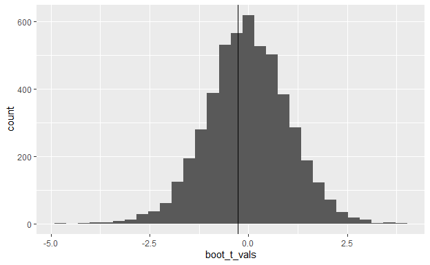

```r
ggplot(data=NULL,mapping=aes(x=boot_t_vals)) + geom_histogram() + geom_vline(xintercept = test_t)
```

How likely is it to obtain the observed t-value assuming the null hypothesis?

Compute the propotion of bootstrap statistic values that are at least as extreme as the observed

```r
sum(boot_t_vals <= test_t)/N
```

```
[1] 0.4024
```

This gives an approximation to the one-sided p-value.

The traditional method for testing this is with a one-sampel t-test:

```r
t.test(x_vals,mu=p_mu,conf.level = ci_percent)
```

```
    One Sample t-test

data:  x_vals
t = -0.26957, df = 29, p-value = 0.7894
alternative hypothesis: true mean is not equal to 3
95 percent confidence interval:
 2.461002 3.413461
sample estimates:
mean of x
 2.937231
```

We would fail to reject the null hypothesis.

### One-sample Example Permutation Test

A one-sample permutation test works by simply looking at the permutation of all possible assignments of positive or negative to the elements in the sample data and then asking what is the probability of getting the observed number of positive values assuming that either sign is equally likely.

For example

```r
test_x <- x_vals - p_mu
(num_plus <- sum(sign(test_x) > 0))
```

```
[1] 13
```

```r
2*(pbinom(num_plus,n,p=0.5))
```

```
[1] 0.5846647
```

Again, we fail to reject the null hypothesis.

**Note:** Between permutation tests and bootstrap t-tests, permutation tests are preferred when it is possible to do them.